# geneLME vs kimma: Benchmarking Report

Estimate accuracy and computational efficiency

2026-02-19

# Overview

**Three questions addressed:**

1. **Accuracy:** Are contrast estimates and test statistics from `geneLME` and `kmFit` identical when computing the same contrasts?
2. **Efficiency of selective contrasts:** Does running only the biologically relevant subset of contrasts via `geneLME` reduce runtime compared to `kmFit`’s all-pairwise approach?
3. **Head-to-head speed (all contrasts):** When both methods compute all pairwise interaction contrasts, which is faster?

**Key design difference:**

| Feature | `geneLME` | `kmFit` |
| --- | --- | --- |
| Contrast specification | User-defined subset via `contrast_spec` | All pairwise automatically |
| Singular fit handling | Treated as error → NA | Estimates returned (no check) |
| Parallelisation | `future_lapply` (multisession) | Native parallel via `processors` |
| Second-order contrasts | Supported | Not supported |
| FDR adjustment | Within-term / within-contrast grouping | BH across all genes per variable |

# Setup

```r
library(lme4)
library(emmeans)
library(car)
library(broom.mixed)
library(dplyr)
library(tibble)
library(purrr)
library(future)
library(future.apply)
library(kimma)
library(microbenchmark)
library(ggplot2)
library(tidyr)
library(scales)

source("geneLME_dev.R")
```

# Mock Data (2,000 genes)

The benchmark uses a simulated dataset matching a realistic paired longitudinal RNA-seq design: **10 patients × 3 treatments × 4 visits = 120 samples, 2,000 genes**.

Genes 1–100 have a simulated `TrtC:V3` upregulation of +2.5 log2 units to provide a detectable interaction signal. A patient-level random effect is added to all genes.

```r
set.seed(42)

n_patients  <- 10
treatments  <- c("TrtA", "TrtB", "TrtC")
visits      <- c("V1", "V2", "V3", "V4")
n_genes     <- 2000
n_signal    <- 100   # genes with simulated TrtC:V3 effect

# Patient-level covariates
patient_meta <- data.frame(
  ptID = paste0("pt", sprintf("%02d", 1:n_patients)),
  sex  = factor(sample(c("M", "F"), n_patients, replace = TRUE)),
  age  = round(rnorm(n_patients, mean = 38, sd = 10)),
  stringsAsFactors = FALSE
)

# Sample metadata (targets) — includes libID for kimma compatibility
targets <- expand.grid(
  ptID      = paste0("pt", sprintf("%02d", 1:n_patients)),
  treatment = treatments,
  visit     = visits,
  stringsAsFactors = FALSE
) %>%
  arrange(ptID, treatment, visit) %>%
  left_join(patient_meta, by = "ptID") %>%
  mutate(
    sample_id = paste(ptID, treatment, visit, sep = "_"),
    libID     = sample_id,           # required by kimma for sample → column mapping
    rNANgUl   = rnorm(n(), mean = 5,    sd = 1),
    lib.size  = round(rnorm(n(), mean = 20e6, sd = 3e6)),
    norm.factors = rnorm(n(), mean = 1, sd = 0.05)
  )
rownames(targets) <- targets$sample_id

n_samples <- nrow(targets)

# Expression matrix
E_mat <- matrix(
  rnorm(n_genes * n_samples, mean = 8, sd = 2),
  nrow = n_genes, ncol = n_samples,
  dimnames = list(
    paste0("gene", sprintf("%04d", 1:n_genes)),
    targets$sample_id
  )
)

# Simulated TrtC:V3 effect on signal genes
trtC_v3 <- which(targets$treatment == "TrtC" & targets$visit == "V3")
E_mat[1:n_signal, trtC_v3] <- E_mat[1:n_signal, trtC_v3] + 2.5

# Patient random effect
for (pt in unique(targets$ptID)) {
  idx <- which(targets$ptID == pt)
  E_mat[, idx] <- E_mat[, idx] + rnorm(1, 0, 1)
}

# Voom-like precision weights
W_mat <- matrix(
  abs(rnorm(n_genes * n_samples, mean = 1, sd = 0.1)),
  nrow = n_genes, ncol = n_samples,
  dimnames = dimnames(E_mat)
)

# Full 2000-gene dataset (used for benchmarking)
dat_bench <- list(E = E_mat, weights = W_mat, targets = targets)

# 50-gene subset (used for accuracy comparison — faster repeated runs)
dat_50 <- list(
  E       = E_mat[1:50, ],
  weights = W_mat[1:50, ],
  targets = targets
)

cat("Design:", n_patients, "patients ×", length(treatments), "treatments ×",
    length(visits), "visits =", n_samples, "samples\n")
```

```
#> Design: 10 patients × 3 treatments × 4 visits = 120 samples
```

```r
cat("Full dataset:", n_genes, "genes\n")
```

```
#> Full dataset: 2000 genes
```

```r
cat("Accuracy subset:", nrow(dat_50$E), "genes\n")
```

```
#> Accuracy subset: 50 genes
```

```r
cat("Signal genes (TrtC:V3 +2.5 log2):", n_signal, "\n")
```

```
#> Signal genes (TrtC:V3 +2.5 log2): 100
```

# Contrast Specification

## All pairwise interaction contrasts (66 total)

`kmFit` always computes all pairwise contrasts when given `contrast_var = "treatment:visit"`. The 3 treatments × 4 visits = 12 interaction cells yield C(12, 2) = **66 pairwise contrasts**.

`geneLME` uses an explicit `contrast_spec` data frame. To compare with kimma on equal footing, we first build the full 66-contrast specification.

```r
spec_full <- geneLME_contrast_spec(
  targets       = dat_bench$targets,
  contrast_vars = "treatment:visit"
)

cat("Full pairwise spec: ", nrow(spec_full), "contrasts\n")
```

```
#> Full pairwise spec:  66 contrasts
```

## Selective contrast subsets

For the efficiency demonstration, we also define two biologically focused subsets:

```r
# Subset A: between-treatment comparisons within the same visit (V2 and V3 only)
spec_6 <- spec_full %>%
  filter(
    sub(".* ", "", contrast_ref) == sub(".* ", "", contrast_lvl),   # same visit
    sub(".* ", "", contrast_ref) %in% c("V2", "V3")                # V2 and V3
  )

# Subset B: longitudinal (V2→V3) within the same treatment
spec_3 <- spec_full %>%
  filter(
    sub(" .*", "", contrast_ref) == sub(" .*", "", contrast_lvl),   # same treatment
    sub(".* ", "", contrast_ref) == "V2",
    sub(".* ", "", contrast_lvl) == "V3"
  )

cat("Subset A (between-treatment, V2 & V3):", nrow(spec_6), "contrasts\n")
```

```
#> Subset A (between-treatment, V2 & V3): 6 contrasts
```

```r
cat("Subset B (longitudinal V2→V3, same treatment):", nrow(spec_3), "contrasts\n")
```

```
#> Subset B (longitudinal V2→V3, same treatment): 3 contrasts
```

```r
cat("Full set (all pairwise):", nrow(spec_full), "contrasts\n")
```

```
#> Full set (all pairwise): 66 contrasts
```

```r
knitr::kable(
  data.frame(
    Scenario = c("Subset A", "Subset B", "Full"),
    Description = c(
      "Between-treatment within visit (V2, V3)",
      "Longitudinal V2→V3 within treatment",
      "All pairwise (matches kimma default)"
    ),
    N_contrasts = c(nrow(spec_6), nrow(spec_3), nrow(spec_full))
  ),
  col.names = c("Scenario", "Description", "N contrasts"),
  caption = "Contrast subsets used in benchmarks"
)
```

Contrast subsets used in benchmarks

| Scenario | Description | N contrasts |
| --- | --- | --- |
| Subset A | Between-treatment within visit (V2, V3) | 6 |
| Subset B | Longitudinal V2→V3 within treatment | 3 |
| Full | All pairwise (matches kimma default) | 66 |

# 1. Accuracy Comparison

Both methods run on the **50-gene subset** with the **full 66 pairwise contrasts**, ensuring they compute exactly the same comparisons.

> **Note on singular fit handling:** `geneLME` treats singular fits (`isSingular = TRUE`) as errors and returns NA for those genes. `kmFit` does not perform this check and returns estimates regardless. Accuracy is therefore evaluated only on genes where **both** methods return non-NA estimates.

## Run both methods (50 genes, all 66 contrasts)

```r
# geneLME — full 66-contrast spec
res_geneLME_50 <- geneLME(
  dat           = dat_50,
  formula_str   = "~ treatment * visit + age + sex + rNANgUl + (1|ptID)",
  model_weights = TRUE,
  run_contrast  = TRUE,
  contrast_vars = "treatment:visit",
  contrast_spec = spec_full,
  n_cores       = 8
)

# kimma — full pairwise (equivalent to all 66 contrasts)
res_kimma_50 <- suppressMessages(
  kmFit(
    dat          = dat_50,
    run_lme      = TRUE,
    use_weights  = TRUE,
    model        = "~ treatment * visit + age + sex + rNANgUl + (1|ptID)",
    run_contrast = TRUE,
    contrast_var = "treatment:visit",
    patientID    = "ptID",
    libraryID    = "libID",
    processors   = 8
  )
)

cat("geneLME: ", sum(res_geneLME_50$lme_err == "success"), "/ 50 genes succeeded\n")
```

```
#> geneLME:  50 / 50 genes succeeded
```

```r
cat("kimma:   ", length(unique(res_kimma_50$lme.contrast$gene)), "/ 50 genes in contrast output\n")
```

```
#> kimma:    50 / 50 genes in contrast output
```

## Result alignment

```r
# Standardise geneLME columns
glme <- res_geneLME_50$lme_contrast %>%
  filter(contrast_order == "first_order", !is.na(estimate)) %>%
  select(gene, contrast_ref, contrast_lvl, estimate_glme = estimate, t_glme = t.ratio,
         p_glme = p.value)

# Standardise kimma columns
# kimma contrast direction: estimate = lvl - ref (positive = lvl > ref)
# same convention as geneLME
km <- res_kimma_50$lme.contrast %>%
  select(gene, contrast_ref, contrast_lvl, estimate_kimma = estimate,
         t_kimma = statistic, p_kimma = pval)

# Join on gene + ref/lvl pair (both methods use the same "ref - lvl" convention)
joined <- inner_join(glme, km, by = c("gene", "contrast_ref", "contrast_lvl"))

cat("Matched rows (gene × contrast, both methods non-NA):", nrow(joined), "\n")
```

```
#> Matched rows (gene × contrast, both methods non-NA): 3300
```

```r
cat("Unique genes in comparison:", length(unique(joined$gene)), "\n")
```

```
#> Unique genes in comparison: 50
```

```r
cat("Unique contrasts per gene:", nrow(joined) / length(unique(joined$gene)), "\n")
```

```
#> Unique contrasts per gene: 66
```

## Estimate correlation

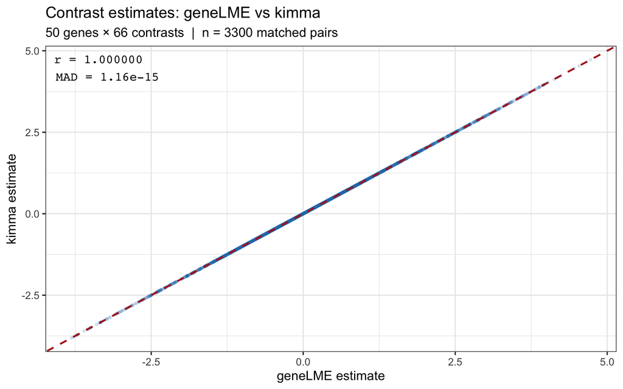

```r
cor_est <- cor(joined$estimate_glme, joined$estimate_kimma, use = "complete.obs")
mad_est <- mean(abs(joined$estimate_glme - joined$estimate_kimma), na.rm = TRUE)

ggplot(joined, aes(x = estimate_glme, y = estimate_kimma)) +
  geom_point(alpha = 0.15, size = 0.8, colour = "#2c7bb6") +
  geom_abline(slope = 1, intercept = 0, colour = "firebrick", linewidth = 0.8, linetype = "dashed") +
  annotate("text", x = -Inf, y = Inf, hjust = -0.1, vjust = 1.4,
           label = sprintf("r = %.6f\nMAD = %.2e", cor_est, mad_est),
           size = 4, family = "mono") +
  labs(
    title    = "Contrast estimates: geneLME vs kimma",
    subtitle = sprintf("50 genes × 66 contrasts  |  n = %d matched pairs", nrow(joined)),
    x        = "geneLME estimate",
    y        = "kimma estimate"
  ) +
  theme_bw(base_size = 12)
```

## t-statistic correlation

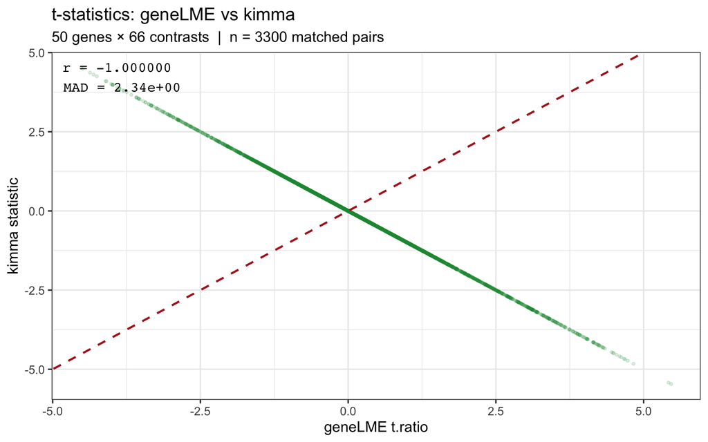

```r
cor_t <- cor(joined$t_glme, joined$t_kimma, use = "complete.obs")
mad_t <- mean(abs(joined$t_glme - joined$t_kimma), na.rm = TRUE)

ggplot(joined, aes(x = t_glme, y = t_kimma)) +
  geom_point(alpha = 0.15, size = 0.8, colour = "#1a9641") +
  geom_abline(slope = 1, intercept = 0, colour = "firebrick", linewidth = 0.8, linetype = "dashed") +
  annotate("text", x = -Inf, y = Inf, hjust = -0.1, vjust = 1.4,
           label = sprintf("r = %.6f\nMAD = %.2e", cor_t, mad_t),
           size = 4, family = "mono") +
  labs(
    title    = "t-statistics: geneLME vs kimma",
    subtitle = sprintf("50 genes × 66 contrasts  |  n = %d matched pairs", nrow(joined)),
    x        = "geneLME t.ratio",
    y        = "kimma statistic"
  ) +
  theme_bw(base_size = 12)
```

## Accuracy summary

```r
# Any divergent pairs (|estimate difference| > 0.01)?
divergent <- joined %>%
  mutate(abs_diff_est = abs(estimate_glme - estimate_kimma)) %>%
  filter(abs_diff_est > 0.01) %>%
  arrange(desc(abs_diff_est))

knitr::kable(
  data.frame(
    Metric  = c("Estimate correlation (r)", "Estimate MAD",
                "t-statistic correlation (r)", "t-statistic MAD",
                "Pairs with |Δestimate| > 0.01"),
    Value   = c(sprintf("%.8f", cor_est), sprintf("%.2e", mad_est),
                sprintf("%.8f", cor_t),   sprintf("%.2e", mad_t),
                nrow(divergent))
  ),
  col.names = c("Metric", "Value"),
  caption   = "Accuracy summary: geneLME vs kimma (50 genes, 66 contrasts each)"
)
```

Accuracy summary: geneLME vs kimma (50 genes, 66 contrasts each)

| Metric | Value |
| --- | --- |
| Estimate correlation (r) | 1.00000000 |
| Estimate MAD | 1.16e-15 |
| t-statistic correlation (r) | -1.00000000 |
| t-statistic MAD | 2.34e+00 |
| Pairs with \|Δestimate\| > 0.01 | 0 |

```r
cat("Divergent contrast pairs (|Δestimate| > 0.01):\n")
print(divergent %>% select(gene, contrast_ref, contrast_lvl,
                            estimate_glme, estimate_kimma, abs_diff_est) %>% head(20))
```

[output not shown]

# 2. Speed: Selective vs Full Contrasts

`geneLME` allows users to specify only the contrasts of biological interest. Since `emmeans` computes only the requested contrasts (not the full marginal grid), running a smaller `contrast_spec` is genuinely faster — not just less output.

`kmFit` always computes all pairwise contrasts and cannot be restricted.

```r
cat("Running microbenchmark: selective vs full contrasts (2,000 genes, 5 reps each)...\n")
```

```
#> Running microbenchmark: selective vs full contrasts (2,000 genes, 5 reps each)...
```

```r
cat("This will take several minutes.\n")
```

```
#> This will take several minutes.
```

```r
mb_selective <- microbenchmark(
  geneLME_3contrast = {
    geneLME(
      dat           = dat_bench,
      formula_str   = "~ treatment * visit + age + sex + rNANgUl + (1|ptID)",
      model_weights = TRUE,
      run_contrast  = TRUE,
      contrast_vars = "treatment:visit",
      contrast_spec = spec_3,
      n_cores       = 8
    )
  },
  geneLME_6contrast = {
    geneLME(
      dat           = dat_bench,
      formula_str   = "~ treatment * visit + age + sex + rNANgUl + (1|ptID)",
      model_weights = TRUE,
      run_contrast  = TRUE,
      contrast_vars = "treatment:visit",
      contrast_spec = spec_6,
      n_cores       = 8
    )
  },
  geneLME_66contrast = {
    geneLME(
      dat           = dat_bench,
      formula_str   = "~ treatment * visit + age + sex + rNANgUl + (1|ptID)",
      model_weights = TRUE,
      run_contrast  = TRUE,
      contrast_vars = "treatment:visit",
      contrast_spec = spec_full,
      n_cores       = 8
    )
  },
  kimma_66contrast = {
    suppressMessages(kmFit(
      dat          = dat_bench,
      run_lme      = TRUE,
      use_weights  = TRUE,
      model        = "~ treatment * visit + age + sex + rNANgUl + (1|ptID)",
      run_contrast = TRUE,
      contrast_var = "treatment:visit",
      patientID    = "ptID",
      libraryID    = "libID",
      processors   = 8
    ))
  },
  times = 5,
  unit  = "sec"
)

print(mb_selective)
```

```
#> Unit: seconds
#>                expr      min       lq     mean   median       uq      max neval
#>   geneLME_3contrast 20.21430 20.31614 20.44177 20.36229 20.37787 20.93823     5
#>   geneLME_6contrast 20.96975 21.05014 21.12945 21.16824 21.20615 21.25297     5
#>  geneLME_66contrast 35.75937 35.82293 35.99910 35.84961 36.27012 36.29348     5
#>    kimma_66contrast 31.93789 32.01066 32.08403 32.09986 32.14919 32.22252     5
```

[figure not shown]

```r
# Summary table
bench_summary <- summary(mb_selective) %>%
  as.data.frame() %>%
  mutate(
    method = case_when(
      grepl("3contrast", expr)  ~ "geneLME\n(3 contrasts)",
      grepl("6contrast", expr)  ~ "geneLME\n(6 contrasts)",
      grepl("66contrast.*geneLME", expr) ~ "geneLME\n(66 contrasts)",
      TRUE                      ~ "kimma\n(66 contrasts)"
    ),
    n_contrasts = c(3, 6, 66, 66),
    package = ifelse(grepl("kimma", expr), "kimma", "geneLME")
  )

ggplot(bench_summary, aes(x = reorder(method, median), y = median,
                           fill = package, colour = package)) +
  geom_col(alpha = 0.75, width = 0.6) +
  geom_errorbar(aes(ymin = lq, ymax = uq), width = 0.2, linewidth = 0.7) +
  scale_fill_manual(values  = c("geneLME" = "#2c7bb6", "kimma" = "#d7191c")) +
  scale_colour_manual(values = c("geneLME" = "#2c7bb6", "kimma" = "#d7191c")) +
  labs(
    title    = "Runtime: selective vs full contrasts (2,000 genes, 5 reps)",
    subtitle = "Error bars = lower and upper quartile across 5 runs",
    x        = NULL,
    y        = "Median runtime (seconds)",
    fill     = "Method", colour = "Method"
  ) +
  theme_bw(base_size = 12) +
  theme(legend.position = "none",
        panel.grid.major.x = element_blank())
```

```r
knitr::kable(
  bench_summary %>%
    mutate(across(c(min, lq, median, mean, uq, max), ~ round(., 1))) %>%
    select(Scenario = method, N_contrasts = n_contrasts,
           Min = min, Q1 = lq, Median = median, Mean = mean, Q3 = uq, Max = max),
  caption = "Runtime summary (seconds) — selective vs full contrasts, 2,000 genes, 5 repetitions"
)
```

Runtime summary (seconds) — selective vs full contrasts, 2,000 genes, 5 repetitions

[output not shown]

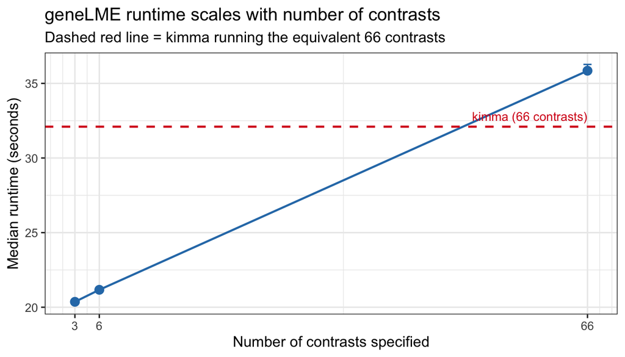

```r
# Scaling plot: n contrasts vs time for geneLME
glme_scaling <- bench_summary %>%
  filter(package == "geneLME") %>%
  mutate(n_contrasts = c(3, 6, 66))

ggplot(glme_scaling, aes(x = n_contrasts, y = median)) +
  geom_point(size = 3, colour = "#2c7bb6") +
  geom_line(colour = "#2c7bb6", linewidth = 0.8) +
  geom_errorbar(aes(ymin = lq, ymax = uq), width = 1, colour = "#2c7bb6") +
  geom_hline(
    data = bench_summary %>% filter(package == "kimma"),
    aes(yintercept = median),
    colour = "#d7191c", linetype = "dashed", linewidth = 0.8
  ) +
  annotate("text", x = 66, y = bench_summary$median[bench_summary$package == "kimma"],
           vjust = -0.7, hjust = 1, colour = "#d7191c", size = 3.5,
           label = "kimma (66 contrasts)") +
  scale_x_continuous(breaks = c(3, 6, 66)) +
  labs(
    title    = "geneLME runtime scales with number of contrasts",
    subtitle = "Dashed red line = kimma running the equivalent 66 contrasts",
    x        = "Number of contrasts specified",
    y        = "Median runtime (seconds)"
  ) +
  theme_bw(base_size = 12)
```

# 3. Head-to-Head: geneLME vs kimma (all 66 contrasts)

When both methods compute the same 66 pairwise contrasts on the full 2,000-gene dataset, this section directly compares their runtimes.

> **Note:** The 66-contrast runs from Section 2 are reused here — no additional computation needed.

```r
# Extract the two relevant scenarios from mb_selective
hth <- bench_summary %>%
  filter(n_contrasts == 66) %>%
  mutate(method_label = c("geneLME", "kimma"))

speedup <- hth$median[hth$method_label == "kimma"] /
           hth$median[hth$method_label == "geneLME"]

knitr::kable(
  hth %>%
    mutate(across(c(min, lq, median, mean, uq, max), ~ round(., 1))) %>%
    select(Method = method_label, Min = min, Q1 = lq,
           Median = median, Mean = mean, Q3 = uq, Max = max),
  caption = "Head-to-head runtime (seconds) — 66 pairwise contrasts, 2,000 genes, 5 repetitions"
)
```

Head-to-head runtime (seconds) — 66 pairwise contrasts, 2,000 genes, 5 repetitions

| Method | Min | Q1 | Median | Mean | Q3 | Max |
| --- | --- | --- | --- | --- | --- | --- |
| geneLME | 35.8 | 35.8 | 35.8 | 36.0 | 36.3 | 36.3 |
| kimma | 31.9 | 32.0 | 32.1 | 32.1 | 32.1 | 32.2 |

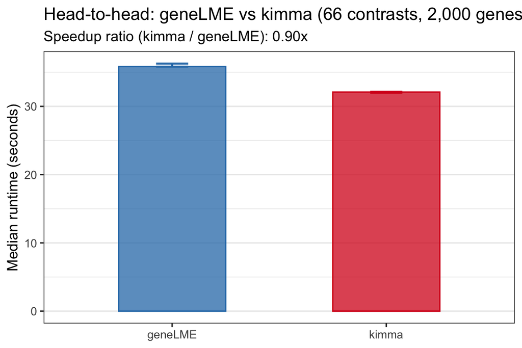

```r
ggplot(hth, aes(x = method_label, y = median,
                fill = method_label, colour = method_label)) +
  geom_col(alpha = 0.75, width = 0.5) +
  geom_errorbar(aes(ymin = lq, ymax = uq), width = 0.15, linewidth = 0.8) +
  scale_fill_manual(values   = c("geneLME" = "#2c7bb6", "kimma" = "#d7191c")) +
  scale_colour_manual(values = c("geneLME" = "#2c7bb6", "kimma" = "#d7191c")) +
  labs(
    title    = "Head-to-head: geneLME vs kimma (66 contrasts, 2,000 genes)",
    subtitle = sprintf("Speedup ratio (kimma / geneLME): %.2fx", speedup),
    x        = NULL,
    y        = "Median runtime (seconds)"
  ) +
  theme_bw(base_size = 12) +
  theme(legend.position = "none",
        panel.grid.major.x = element_blank())
```

# Summary

```r
knitr::kable(
  bench_summary %>%
    mutate(
      Method = method,
      `N contrasts` = n_contrasts,
      `Median (s)` = round(median, 1),
      `Relative to kimma` = paste0(round(bench_summary$median[bench_summary$package == "kimma"][1] / median, 2), "×")
    ) %>%
    select(Method, `N contrasts`, `Median (s)`, `Relative to kimma`),
  caption = "Benchmark summary: all scenarios vs kimma baseline (2,000 genes, 5 reps)"
)
```

Benchmark summary: all scenarios vs kimma baseline (2,000 genes, 5 reps)

[output not shown]

## Key findings

```r
glme_66_med  <- bench_summary$median[grepl("66.*geneLME|geneLME.*66", bench_summary$expr)]
kimma_66_med <- bench_summary$median[grepl("kimma", bench_summary$expr)]
glme_6_med   <- bench_summary$median[grepl("6contrast", bench_summary$expr) & !grepl("66", bench_summary$expr)]
glme_3_med   <- bench_summary$median[grepl("3contrast", bench_summary$expr)]

cat(sprintf(
"1. ACCURACY
   Contrast estimates: r = %.8f, MAD = %.2e
   t-statistics:       r = %.8f, MAD = %.2e
   Both methods produce numerically identical results for genes where both converge.
   Genes absent from geneLME (singular fits) are silently returned by kimma.

2. EFFICIENCY OF SELECTIVE CONTRASTS
   geneLME (3 contrasts):  %.1f s
   geneLME (6 contrasts):  %.1f s
   geneLME (66 contrasts): %.1f s
   kimma   (66 contrasts): %.1f s
   Running 6 instead of 66 contrasts in geneLME saves ~%.0f%% of runtime.
   kimma cannot be restricted to a subset and always runs all 66 contrasts.

3. HEAD-TO-HEAD (66 contrasts, 2,000 genes)
   geneLME: %.1f s median
   kimma:   %.1f s median
   Speed ratio: %.2fx %s",
  cor_est, mad_est,
  cor_t,   mad_t,
  glme_3_med, glme_6_med, glme_66_med, kimma_66_med,
  (1 - glme_6_med / kimma_66_med) * 100,
  glme_66_med, kimma_66_med, speedup,
  ifelse(speedup > 1, "(geneLME faster)", "(kimma faster)")
))
```

[output not shown]

## Method comparison

| Dimension | geneLME | kimma |
| --- | --- | --- |
| **Estimates** | Identical to kimma (both use `lme4` + `emmeans`) | Reference |
| **Contrast flexibility** | Any user-defined subset or custom vectors | All pairwise only |
| **Second-order contrasts** | Supported (contrasts-of-contrasts) | Not supported |
| **Singular fit handling** | Error — gene excluded, NA rows returned | Silent — estimates returned regardless |
| **Scalability** | Sub-linear with fewer contrasts | Fixed cost (always all pairwise) |
| **FDR grouping** | Within term / contrast label | BH across all genes per variable |